# Interactions

Key

Due: November 20, 2018

# Content Knowledge

1. Describe in everyday (non-statistical) language (a) what an interaction is,
   2. what it allows you to evaluate, and (c) how models with interactions differ from models without interactions.

An interaction allows the analyst to evaluate if the effect or impact of something, say, an intervention, depends on something else. In other words, under certain conditions the effect may be very large, but under other conditions it is small. Including models with interaction terms allows the analyst to evaluate whether this is the case or not be evaluating how an effect or relation differs (or does not differ) across levels of another variable. These models differ from other models by essentially allowing one variable to have multiple slopes, one for each level of the theoretical moderator, rather than parallel slopes across the variable.

2. Briefly (3 sentences max) describe the process of centering and describe why it can be helpful.

Centering is when you subtract a constant value - often the grand mean - from a variable. It is helpful because (a) it can often help make the intercept more interpretable, and (b) it can reduce collinearity in the model, particularly when variables are created from other varaibles in the data.

3. Briefly (3 sentences max) describe the interpretation of standardized coefficients. Compare/contrast their interpretation in simple and multiple linear regression.

Standardized coefficients represent the expected standard deviation change in the outcome, given a one standard deviation increase in the corresponding IV. The interpretation in MR is the same as other coefficients - the expected SD change while controlling for all other variables in the model. In simple linear regression, the standardized coefficient is equivalent to Pearson’s correlation.

# Applied Practice

1. Use the code chunk below to import the “adoption.sav” dataset

```r
library(tidyverse)
library(rio)
library(here)
theme_set(theme_minimal())

d <- import(here("data", "adoption.csv"),
            setclass = "tbl_df")
head(d)
```

```
## # A tibble: 6 x 8
##      id    openness prenatal_drug  distresslim distressnov struc_parenting
##   <int>       <dbl> <chr>                <dbl>       <dbl>           <dbl>
## 1   318  1.444828   Parent Prenat…   1.000347   -0.8287795      -0.5973437
## 2   212 -0.07131860 Parent Prenat…  -0.8648728   0.4061353       0.8054452
## 3    77 -1.504978   Parent Prenat…   0.4200396   0.9935895      -1.411866
## 4   118  0.9382995  Parent Prenat…   1.223523   -0.5522103       0.7601940
## 5   291  0.1805225  Parent Prenat…  -1.392765    0.5763151       1.031702
## 6   185 -0.5806945  Parent Prenat…  -0.6163860   0.9014959      -1.230861
## # ... with 2 more variables: bm_psychopathology <dbl>,
## #   behav_prob_score <dbl>
```

The specific research question for this study relates to the relation between structured parenting levels (`struc_parenting`) and children’s distress to novel situation (`distressnov`) with children’s overall behavioral problems (the dependent variable).

In the code chunk below, produce at least two exploratory plots that relate to the research purpose.

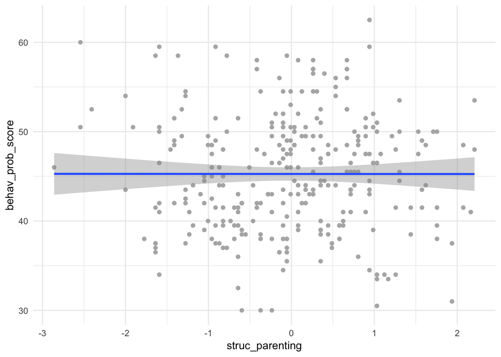

```r
ggplot(d, aes(struc_parenting, behav_prob_score)) +
  geom_point(color = "gray70") +
  geom_smooth(method = "lm")
```

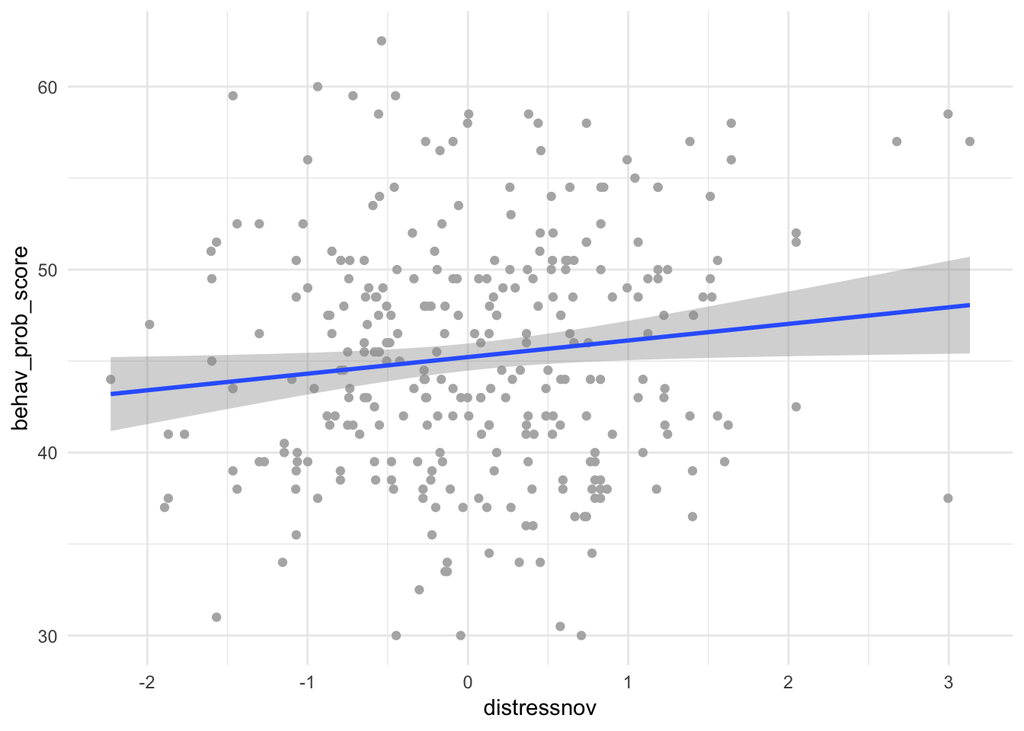

```r
ggplot(d, aes(distressnov, behav_prob_score)) +
  geom_point(color = "gray70") +
  geom_smooth(method = "lm")
```

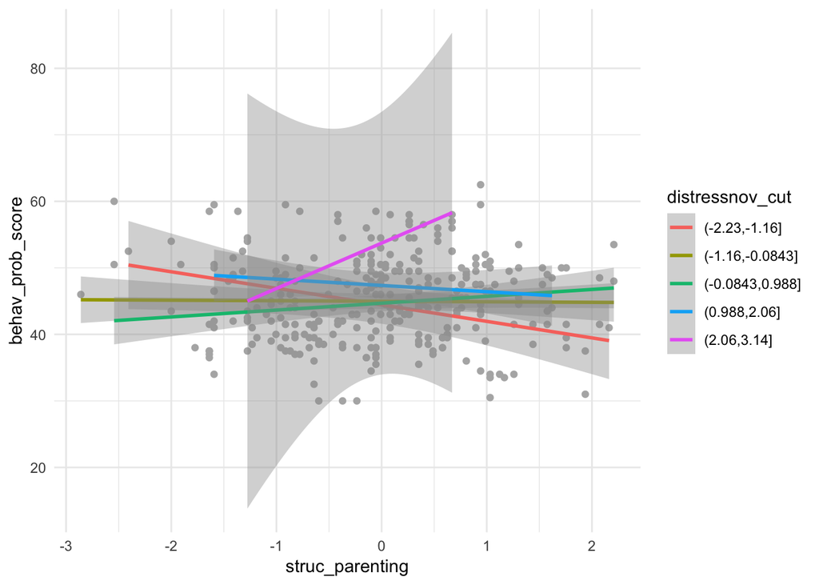

```r
d %>%
  mutate(distressnov_cut = cut(distressnov, 5)) %>%
  ggplot(aes(struc_parenting, behav_prob_score)) +
  geom_point(color = "gray70") +
  geom_smooth(method = "lm",
              aes(color = distressnov_cut))
```

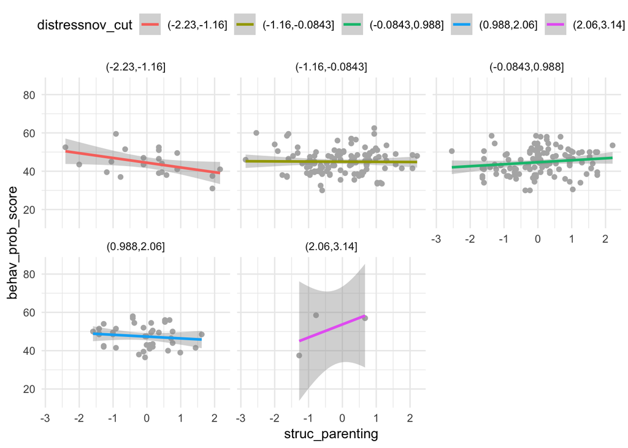

```r
d %>%
  mutate(distressnov_cut = cut(distressnov, 5)) %>%
  ggplot(aes(struc_parenting, behav_prob_score)) +
  geom_point(color = "gray70") +
  geom_smooth(method = "lm",
              aes(color = distressnov_cut)) +
  facet_wrap(~distressnov_cut) +
  theme(legend.position = "top")
```

In the code chunk below, fit a model that addersses the research purpose using a parallel slopes model. Fit the model such that the intercept represents the average behavior problem score for children who displayed average distress to novel situations and had parents who provided average strucuture.

```r
d <- d %>%
  mutate(struc_parenting_c = scale(struc_parenting, scale = FALSE),
         distressnov_c = scale(distressnov, scale = FALSE))

m1 <- lm(behav_prob_score ~ struc_parenting_c + distressnov_c, data = d)
summary(m1)
```

```
##
## Call:
## lm(formula = behav_prob_score ~ struc_parenting_c + distressnov_c,
##     data = d)
##
## Residuals:
##      Min       1Q   Median       3Q      Max
## -15.8527  -4.8181   0.1497   4.2992  17.7340
##
## Coefficients:
##                   Estimate Std. Error t value Pr(>|t|)
## (Intercept)       45.26510    0.37700 120.068   <2e-16 ***
## struc_parenting_c  0.03962    0.39316   0.101   0.9198
## distressnov_c      0.90914    0.42024   2.163   0.0313 *
## ---
## Signif. codes:  0 '***' 0.001 '**' 0.01 '*' 0.05 '.' 0.1 ' ' 1
##
## Residual standard error: 6.508 on 295 degrees of freedom
## Multiple R-squared:  0.01562,    Adjusted R-squared:  0.008944
## F-statistic:  2.34 on 2 and 295 DF,  p-value: 0.0981
```

```r
confint(m1)
```

```
##                         2.5 %     97.5 %
## (Intercept)       44.52315711 46.0070442
## struc_parenting_c -0.73413295  0.8133698
## distressnov_c      0.08208567  1.7361902
```

```r
lmSupport::modelEffectSizes(m1)
```

```
## lm(formula = behav_prob_score ~ struc_parenting_c + distressnov_c,
##     data = d)
##
## Coefficients
##                           SSR df pEta-sqr dR-sqr
## (Intercept)       610580.9430  1   0.9799     NA
## struc_parenting_c      0.4301  1   0.0000 0.0000
## distressnov_c        198.2219  1   0.0156 0.0156
##
## Sum of squared errors (SSE): 12494.3
## Sum of squared total  (SST): 12692.6
```

Provide a full interpretation of the model below. Use the code chunk above to run any other functions you may need to provide this interpretation (but do not change the model itself).

Children who displayed distress to novel situations equal to the sample average, with parents who exhibited structured parenting levels equal to the sample average, had an average behavioral problem score of 45.27. The lower and upper bounds of the 95% confidence interval were 44.52 and 46.01, respectively. Structured parenting levels did not significantly relate to problem behavior scores, while controlling for distress to novel situations. By contrast, distress to novel situations did significantly relate to child behavior problem scores, with a one unit increase in destress to novel situations corresponding to, on average, a 0.91 unit increase in child behavior problem scores ($SE = 0.42, t(295) = 2.16, p = 0.03$). The model overall accounted for 1.6% of the total variance in child behavior problem scores, which was nearly entirely uniquely attributable to distress to novel situations.

2. Refit the model in the code chunk below to specify structured parenting as a moderator of the distress to novel situations slope.

```r
m2 <- lm(behav_prob_score ~ struc_parenting_c*distressnov_c, data = d)
summary(m2)
```

```
##
## Call:
## lm(formula = behav_prob_score ~ struc_parenting_c * distressnov_c,
##     data = d)
##
## Residuals:
##      Min       1Q   Median       3Q      Max
## -16.0313  -4.8147  -0.1834   4.3155  18.1792
##
## Coefficients:
##                                 Estimate Std. Error t value Pr(>|t|)
## (Intercept)                      45.3096     0.3748 120.902   <2e-16 ***
## struc_parenting_c                 0.1560     0.3936   0.396   0.6921
## distressnov_c                     0.9577     0.4177   2.293   0.0226 *
## struc_parenting_c:distressnov_c   1.0108     0.4383   2.306   0.0218 *
## ---
## Signif. codes:  0 '***' 0.001 '**' 0.01 '*' 0.05 '.' 0.1 ' ' 1
##
## Residual standard error: 6.461 on 294 degrees of freedom
## Multiple R-squared:  0.03311,    Adjusted R-squared:  0.02324
## F-statistic: 3.356 on 3 and 294 DF,  p-value: 0.01929
```

```r
confint(m2)
```

```
##                                      2.5 %     97.5 %
## (Intercept)                     44.5720559 46.0471769
## struc_parenting_c               -0.6185319  0.9305792
## distressnov_c                    0.1355791  1.7798196
## struc_parenting_c:distressnov_c  0.1482330  1.8733301
```

```r
lmSupport::modelEffectSizes(m2)
```

```
## lm(formula = behav_prob_score ~ struc_parenting_c * distressnov_c,
##     data = d)
##
## Coefficients
##                                         SSR df pEta-sqr dR-sqr
## (Intercept)                     610159.6173  1   0.9803     NA
## struc_parenting_c                    6.5605  1   0.0005 0.0005
## distressnov_c                      219.4046  1   0.0176 0.0173
## struc_parenting_c:distressnov_c    222.0268  1   0.0178 0.0175
##
## Sum of squared errors (SSE): 12272.3
## Sum of squared total  (SST): 12692.6
```

3. Calculate standardized coefficients for m2 in the code chunk below, then interpret the standardized coefficients for the interaction term below.

```r
lm.beta::lm.beta(m2)
```

```
##
## Call:
## lm(formula = behav_prob_score ~ struc_parenting_c * distressnov_c,
##     data = d)
##
## Standardized Coefficients::
##                     (Intercept)               struc_parenting_c
##                      0.00000000                      0.02295411
##                   distressnov_c struc_parenting_c:distressnov_c
##                      0.13181586                      0.13348762
```

A one standard deviation increase in structured parenting corresponded to, on average, a 0.13 standard deviation increase in the distress to novel situations slope.

3. Modify the code below to produce a coefficient plot of m2.

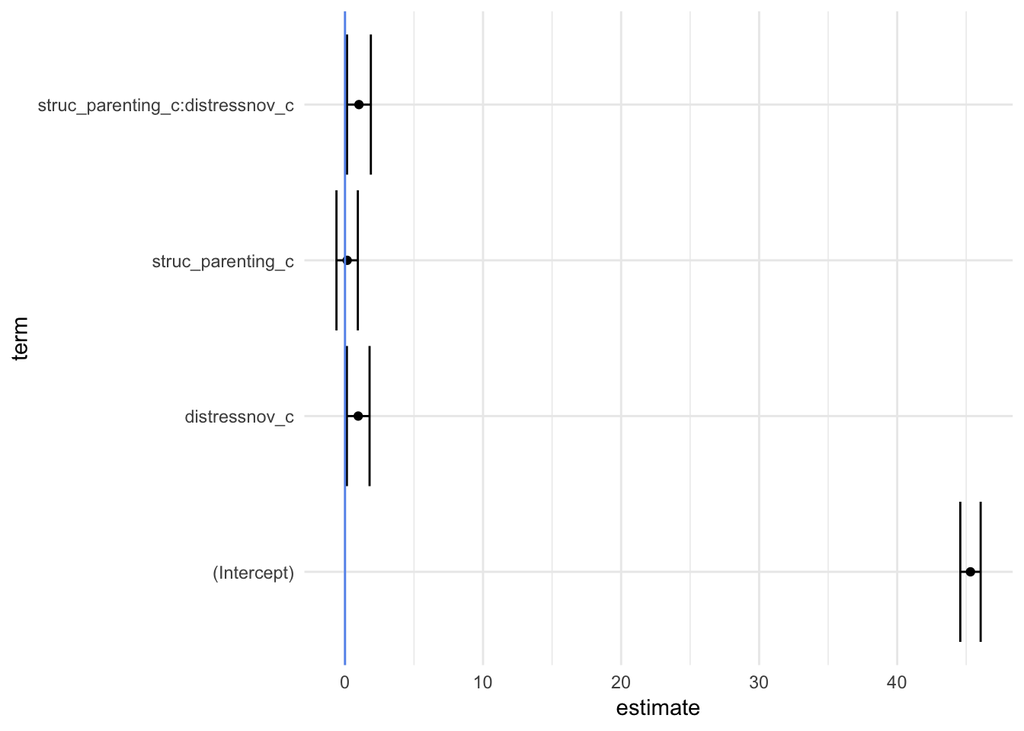

```r
library(broom)
tidy_pd <- tidy(m2, conf.int = TRUE)

ggplot(tidy_pd, aes(term, estimate)) +
  geom_point() +
  geom_errorbar(aes(ymin = conf.low, ymax = conf.high)) +
  geom_hline(yintercept = 0, color = "cornflowerblue") +
  coord_flip()
```

4. Investigate the assumptions of m2 in the code chunk below. Following your investigation, report whether or not you think the model meets the assumptions.

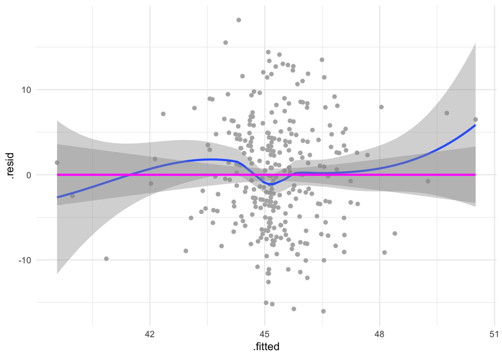

```r
ggplot(m2, aes(.fitted, .resid)) +
  geom_point(color = "gray70") +
  geom_smooth() +
  geom_smooth(method = "lm",
              color = "magenta")
```

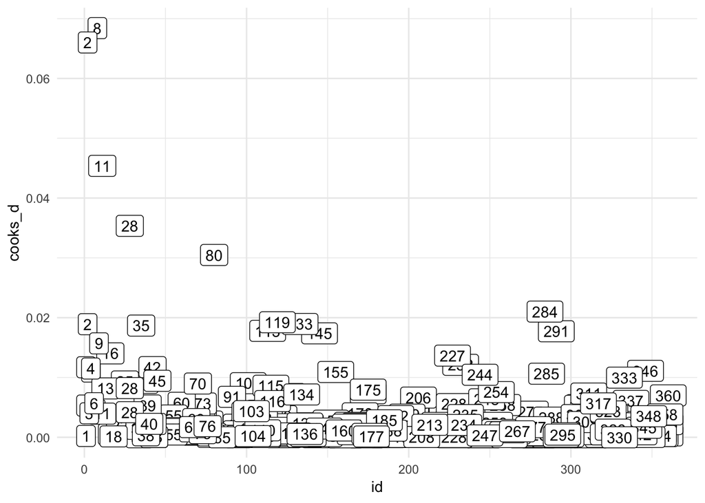

```r
d <- d %>%
  mutate(cooks_d = cooks.distance(m2))

ggplot(d, aes(id, cooks_d)) +
  geom_label(aes(label = id))
```

```r
d %>%
  select(cooks_d) %>%
  arrange(desc(cooks_d))
```

```
## # A tibble: 298 x 1
##       cooks_d
##         <dbl>
##  1 0.06841428
##  2 0.06601343
##  3 0.04538495
##  4 0.03535246
##  5 0.03048625
##  6 0.02101939
##  7 0.01923806
##  8 0.01894093
##  9 0.01891255
## 10 0.01867628
## # ... with 288 more rows
```

The plot of the fitted values against the model residuals displayed evidence of a relation indicating possible divergence from the independence of observations assumption. However, when a linear model was fit to the relation instead of a LOESS regression, the line was nearly perfectly flat and centered on zero, indicating that the relation observed with LOESS regression was likely due to a few outlier points.

In terms of outliers, none of the points displayed evidnece of being unduly influential on the regression space, with the largest Cook’s D being less than 0.07.